# RNA-seq differential exon usage

Michael Hunt

29 April 2016

[Book page: RNA-seq differential exon usage](http://genomicsclass.github.io/book/pages/rnaseq_exon_usage.html)

## Exon usage assessment

We will look for differential exon usage in the same experimental data as shown in the video, but we will use a different subset of the genes (to speed up the time required for analysis on student’s laptops).

Build a DEXSeq dataset object:

```r
library("pasilla")
inDir = system.file("extdata", package="pasilla", mustWork=TRUE)
countFiles = list.files(inDir, pattern="fb.txt$", full.names=TRUE)
flattenedFile = list.files(inDir, pattern="gff$", full.names=TRUE) # gives info about the exonic parts

sampleTable = data.frame(row.names = c( "treated1", "treated2", "treated3","untreated1", "untreated2", "untreated3", "untreated4" ), condition = c("knockdown", "knockdown", "knockdown", "control", "control", "control", "control" ))

library("DEXSeq")
dxd = DEXSeqDataSetFromHTSeq(countFiles, sampleData=sampleTable,
  design= ~ sample + exon + condition:exon, flattenedfile=flattenedFile )
```

For explanation of the design, see the DEXSeq Vignette.

```r
rmean = rowMeans(counts(dxd))
```

We use rowRanges to pull out chr2L:

```r
dxd2L = dxd[seqnames(rowRanges(dxd)) == "chr2L" & rmean > 10,]
```

Now subset to first 1000:

```r
dxd2L = dxd2L[1:1000,]
```

Now we run the estimation and testing functions:

```r
dxd2L = estimateSizeFactors( dxd2L)
dxd2L = estimateDispersions( dxd2L )
```

```
## using supplied model matrix
## using supplied model matrix
```

```r
dxd2L= testForDEU(dxd2L )
```

```
## using supplied model matrix
```

```r
dxd2L = estimateExonFoldChanges( dxd2L, fitExpToVar="condition")
```

### Exon usage Q1

What is the gene name of the gene with the exon with the smallest adjusted p-value for differntial exon usage? (The gene name is the part FBgn…, before the ‘:’ and the exon number, E001. So stop before the ‘:’)

```r
dxr = DEXSeqResults( dxd2L )
pAdjMinGene<-rownames(dxr)[ which.min(dxr$padj) ]
pAdjMinGene<-sub(":.*", "", pAdjMinGene) # extract everyuthing up to the colon
pAdjMinGene
```

```
## [1] "FBgn0000256"
```

Now we make an MA-plot, and draw the expression levels over the exons to highlight differential exon usage:

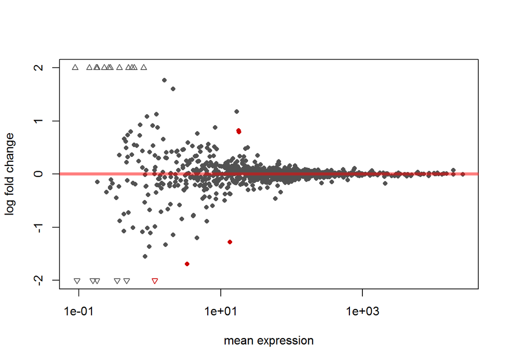

```r
plotMA( dxr, cex=0.8 )
```

### Exon usage Q2

Make a DEXSeq plot of the DEXSeq results object for this gene.

Use the settings:

norCounts=TRUE, displayTranscripts=TRUE

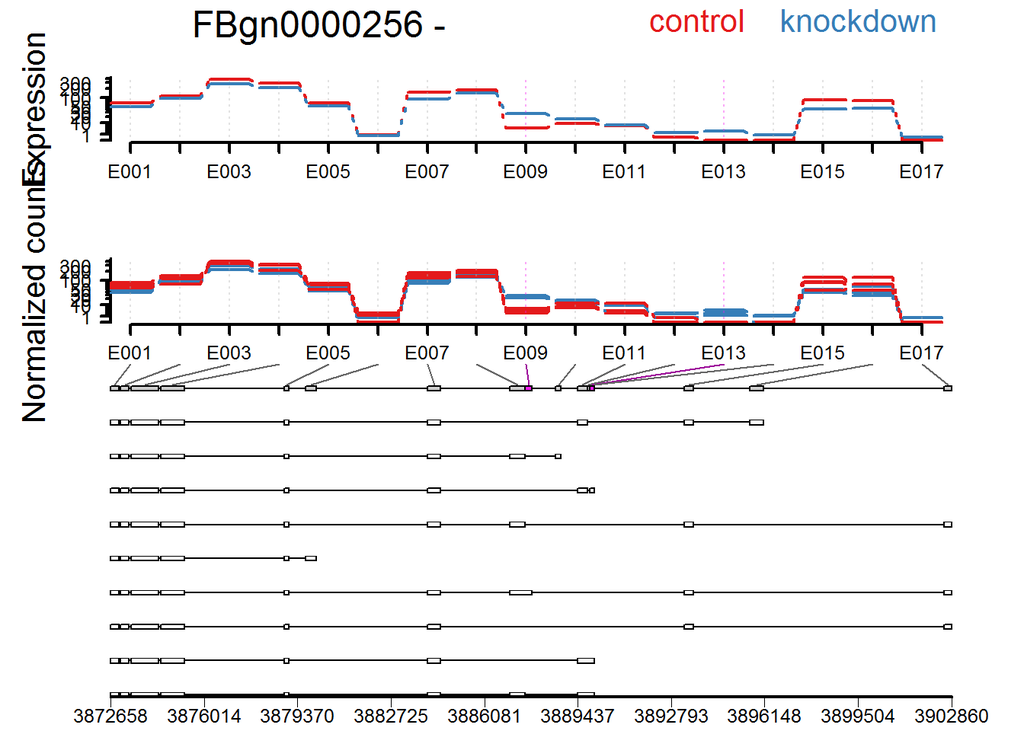

```r
plotDEXSeq( dxr, pAdjMinGene, displayTranscripts=TRUE, legend=TRUE,
              cex.axis=1.2,cex=1.3,lwd=2,norCounts=TRUE)
```

You should see two exonic parts with differential exon usage (colored pink). Exonic part E009 was the one with the smallest p-value in the dataset, consistently knocked down in control samples.

### Exon usage Q2

The transcripts are shown in the white boxes below the plot (the grey boxes just show all the exonic parts). Make the plot as wide as possible to help see the exonic parts. (In RStudio, click the zoom button)

How many transcripts does exonic part E009 appear in?

Answer:  
From the plot, 1, only in transcript 6.

### Exon usage Q3

How many transcripts does exonic part E008 appear in but not exonic part E009?

Answer: 3. From seeing the transcripts below the plot, transcript 2, 4 and 9 have E008 but not E009.

The DEXSeq method was published in Genome Research in 2012:

http://genome.cshlp.org/content/22/10/2008.full

Since then, a number of comparison papers have compared the exon-centric approach to an isoform-centric approach. A recent comparison paper which is worth exploring is this one, published in Genome Biology in 2015:

**Isoform prefiltering improves performance of count-based methods for analysis of differential transcript usage**, Charlotte Soneson, Katarina L. Matthes, Malgorzata Nowicka, Charity W. Law and Mark D. Robinson

http://genomebiology.biomedcentral.com/articles/10.1186/s13059-015-0862-3

The authors find that “[exon] count-based methods generally perform well in the detection of differential transcript usage”, although DEXSeq’s false discovery rate can be improved by filtering out isoforms from the annotation file which are very lowly or not expressed in the samples (see Figure 6).

The choice of exon-centric vs isoform-centric differential analysis is best decided as to what would be more valuable for biological interpretation: do you, or does the biological collaborator want to know which *exons* are being included or excluded across condition, or is it more useful to know the *isoforms* that are differentially expressed across condition?

## Isoform abundance assessment

In this assessment, we will examine the isoform-level abundances which are saved as output from Cufflinks and accessible via the Bioconductor package [cummeRbund](http://www.bioconductor.org/packages/release/bioc/html/cummeRbund.html).

We will eventually ask, for each gene: how often is the most highly expressed isoform the same across two biological conditions?

Start by creating a CuffSet object as we did in the video:

```r
library(cummeRbund)
myDir <- system.file("extdata", package="cummeRbund")
gtfFile <- system.file("extdata/chr1_snippet.gtf",package="cummeRbund")
cuff <- readCufflinks(dir=myDir,gtfFile=gtfFile,genome="hg19",rebuild=TRUE)
```

Extract the annotation information with the annotation() function. This gives exon-level information. We just want to know the gene which each isoform belongs to, so we can remove duplicate rows belonging to the same isoform:

```r
gene.features <- annotation(genes(cuff))
head(gene.features)
```

```
##       gene_id class_code nearest_ref_id gene_short_name            locus
## 1 XLOC_000001       <NA>           <NA>            <NA> chr1:11873-29961
## 2 XLOC_000001       <NA>           <NA>            <NA> chr1:11873-29961
## 3 XLOC_000001       <NA>           <NA>            <NA> chr1:11873-29961
## 4 XLOC_000001       <NA>           <NA>            <NA> chr1:11873-29961
## 5 XLOC_000001       <NA>           <NA>            <NA> chr1:11873-29961
## 6 XLOC_000001       <NA>           <NA>            <NA> chr1:11873-29961
##   length coverage seqnames start   end width strand     source type score
## 1     NA       NA     chr1 11874 12227   354      + nearCoding exon    NA
## 2     NA       NA     chr1 12646 12697    52      + nearCoding exon    NA
## 3     NA       NA     chr1 13221 14409  1189      + nearCoding exon    NA
## 4     NA       NA     chr1 11874 12227   354      +     coding exon    NA
## 5     NA       NA     chr1 12595 12721   127      +     coding exon    NA
## 6     NA       NA     chr1 13403 14409  1007      +     coding exon    NA
##   phase     isoform_id exon_number        oId nearest_ref class_code
## 1    NA TCONS_00000003           1 uc010nxr.1  uc010nxr.1          =
## 2    NA TCONS_00000003           2 uc010nxr.1  uc010nxr.1          =
## 3    NA TCONS_00000003           3 uc010nxr.1  uc010nxr.1          =
## 4    NA TCONS_00000002           1 uc010nxq.1  uc010nxq.1          =
## 5    NA TCONS_00000002           2 uc010nxq.1  uc010nxq.1          =
## 6    NA TCONS_00000002           3 uc010nxq.1  uc010nxq.1          =
##   TSS_group_id CDS_id gene_name
## 1         TSS1   <NA>      <NA>
## 2         TSS1   <NA>      <NA>
## 3         TSS1   <NA>      <NA>
## 4         TSS1     P1      <NA>
## 5         TSS1     P1      <NA>
## 6         TSS1     P1      <NA>
```

```r
isoforms.per.gene <- gene.features[!duplicated(gene.features$isoform_id),    c("gene_id","isoform_id")]
isoforms.per.gene <- isoforms.per.gene[order(isoforms.per.gene$isoform_id),]
head(isoforms.per.gene)
```

```
##        gene_id     isoform_id
## 7  XLOC_000001 TCONS_00000001
## 4  XLOC_000001 TCONS_00000002
## 1  XLOC_000001 TCONS_00000003
## 10 XLOC_000002 TCONS_00000004
## 11 XLOC_000003 TCONS_00000005
## 12 XLOC_000004 TCONS_00000006
```

A single call to table() gives us a vector, one value for each gene, of the number of isoforms per gene:

```r
gene.tab <- table(isoforms.per.gene$gene_id)
```